# cricketr flexes new muscles: The final analysis

# 4. Relative performances of international batsmen against India in India

While England & Australia are famous for bouncy tracks with swing, Indian pitches are renowed for being extraordinary turners. Also India has always thrown up world class spinners, from the spin quartet of BS Chandraskehar, Bishen Singh Bedi, EAS Prasanna, S Venkatraghavan, to the times of dangerous Anil Kumble, and now to the more recent Ravichander Ashwon and Harbhajan Singh.

A batsmen who can score runs in India against Indian spinners has to be really adept in handling all kinds of spin.

While Clive Lloyd & Alvin Kallicharan had the best performance against India, they have not been included as ESPN Cricinfo had many of the columns missing.

So I chose the following international players for the analysis against India 1. Hashim Amla (South Africa) 2. Alastair Cook (England) 3. Matthew Hayden (Australia) 4. Viv Richards (West Indies)

```r
frames <- list("./data/amlaVsIndInInd.csv","./data/ancookVsIndInInd.csv","./data/mhaydenVsIndInInd.csv",
               "./data/vrichardsVsIndInInd.csv")
names <- list("H Amla","AN Cook","M Hayden","Viv Riachards")
```

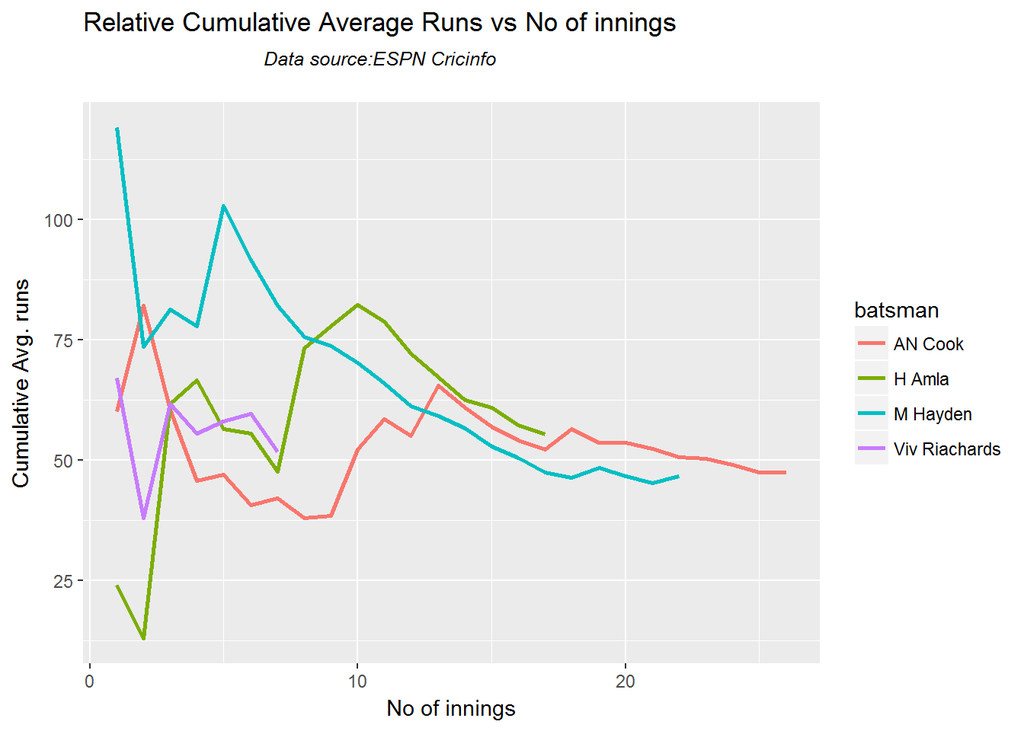

```r
relativeBatsmanCumulativeAvgRuns(frames,names)
```

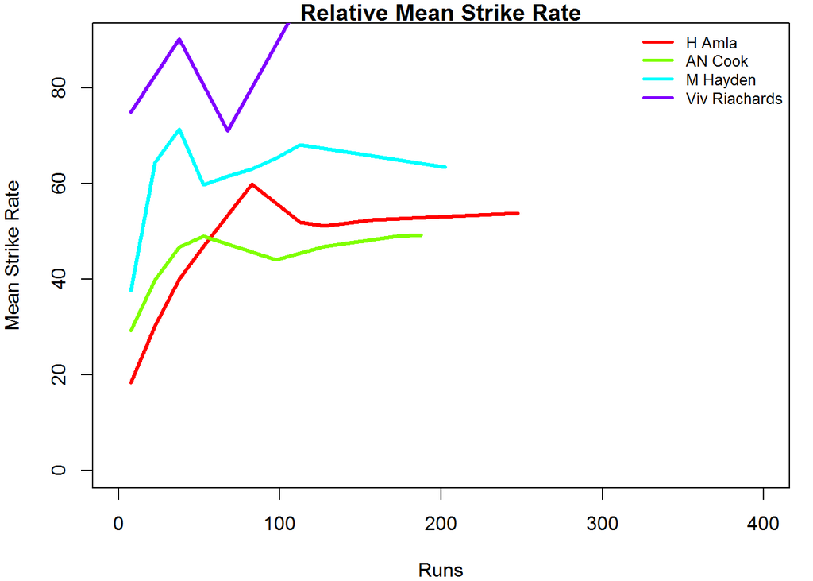

```r
#With respect to strike rate, there is no contest when Viv Richards is around. He is clearly the best
#striker of the ball regardless of whether it is the pacy wickets of Australia/England or the spinning
#tracks of the subcontinent
relativeBatsmanSR(frames,names)
```

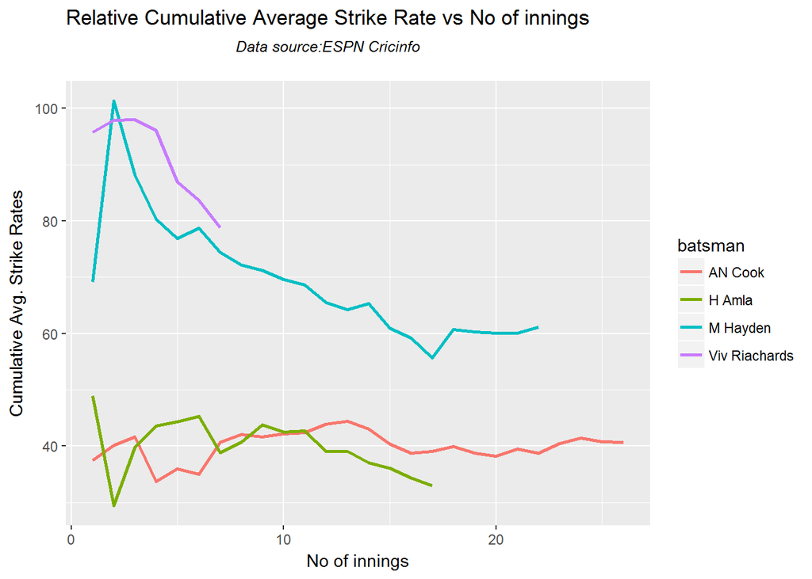

```r
relativeBatsmanCumulativeStrikeRate(frames,names)
```

## 5. All time greats of Indian batting

I couldn’t resist checking out how the top Indian batsmen perform when playing in host countries So here is a look at how the top Indian batsmen perform against different host countries

# 6. Top Indian batsmen against Australia in Australia

The following Indian batsmen were chosen 1. Sunil Gavaskar 2. Sachin Tendulkar 3. Virat Kohli 4. Virendar Sehwag 5. VVS Laxman

```r
frames <- list("./data/tendulkarVsAusInAus.csv","./data/gavaskarVsAusInAus.csv","./data/kohliVsAusInAus.csv",
               "./data/sehwagVsAusInAus.csv","./data/vvslaxmanVsAusInAus.csv")
names <- list("S Tendulkar","S Gavaskar","V Kohli","V Sehwag","VVS Laxman")
```

Virat Kohli has the best overall performance against Australia, with a current cumulative average of 60+ runs for the total number of innings played bu him (15). With 15 matches the 2nd best is Virendar Sehwag, followed by VVS Laxman. Tendulakr maintains a cumulative average of 48+ runs for an excess of 30+ innings.

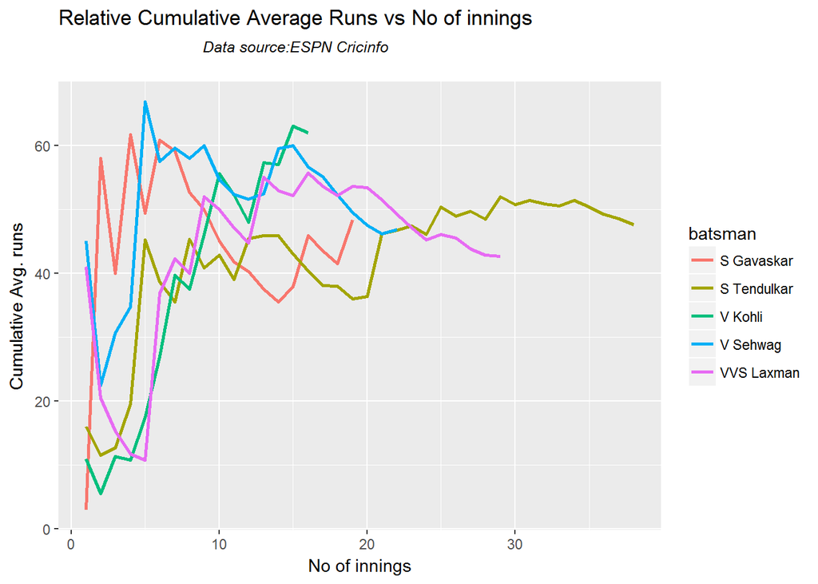

```r
relativeBatsmanCumulativeAvgRuns(frames,names)
```

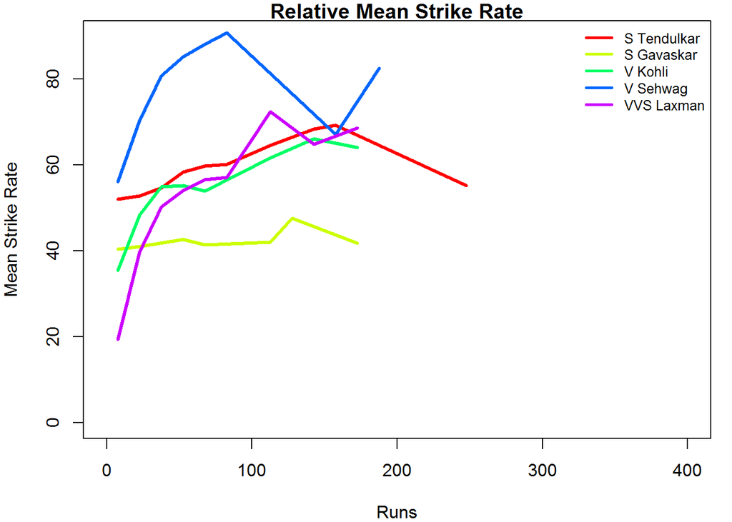

```r
# Sehwag leads the strike rate against host Australia, followed by Tendulkar in Australia
relativeBatsmanSR(frames,names)
```

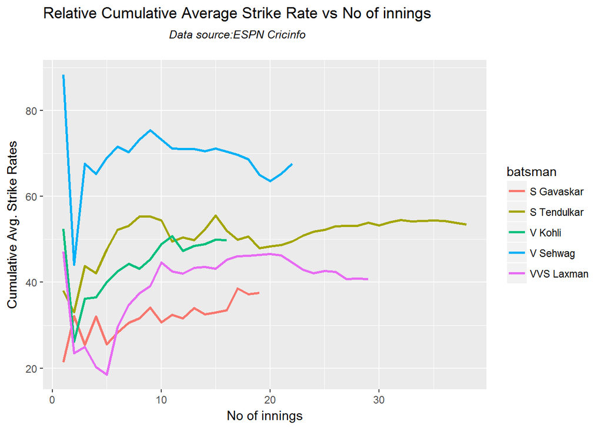

```r
relativeBatsmanCumulativeStrikeRate(frames,names)
```

# 7. Top Indian batsmen against England in England

```r
frames <- list("./data/tendulkarVsEngInEng.csv","./data/dravidVsEngInEng.csv","./data/vengsarkarVsEngInEng.csv",
               "./data/gangulyVsEngInEng.csv","./data/gavaskarVsEngInEng.csv","./data/kohliVsEngInEng.csv")
names <- list("S Tendulkar","R Dravid","D Vengsarkar","S Ganguly","S Gavaskar","V Kohli")
```

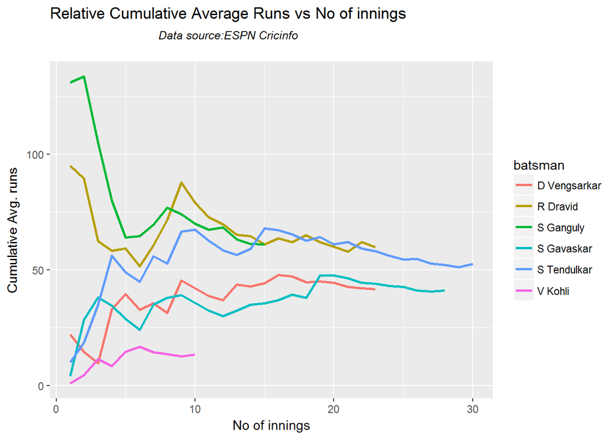

```r
relativeBatsmanCumulativeAvgRuns(frames,names)
```

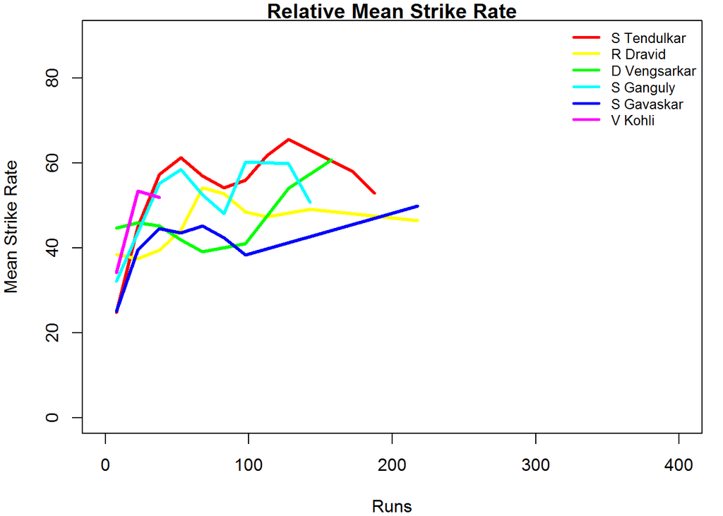

```r
#Tendulkar, Ganguly and Dravid have the best strike rate and in that order.
relativeBatsmanSR(frames,names)
```

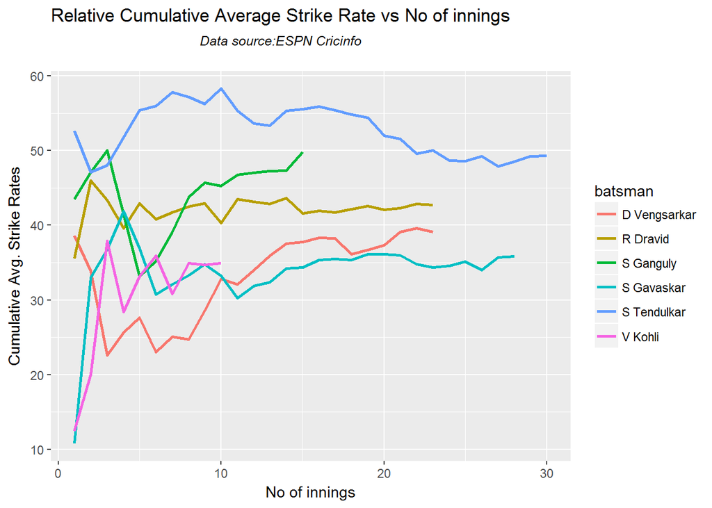

```r
relativeBatsmanCumulativeStrikeRate(frames,names)
```

## 8. Top Indian batsmen against West Indies in West Indies

```r
frames <- list("./data/tendulkarVsWInWI.csv","./data/dravidVsWInWI.csv","./data/vvslaxmanVsWIInWI.csv",
               "./data/gavaskarVsWIInWI.csv")
names <- list("S Tendulkar","R Dravid","VVS Laxman","S Gavaskar")
```

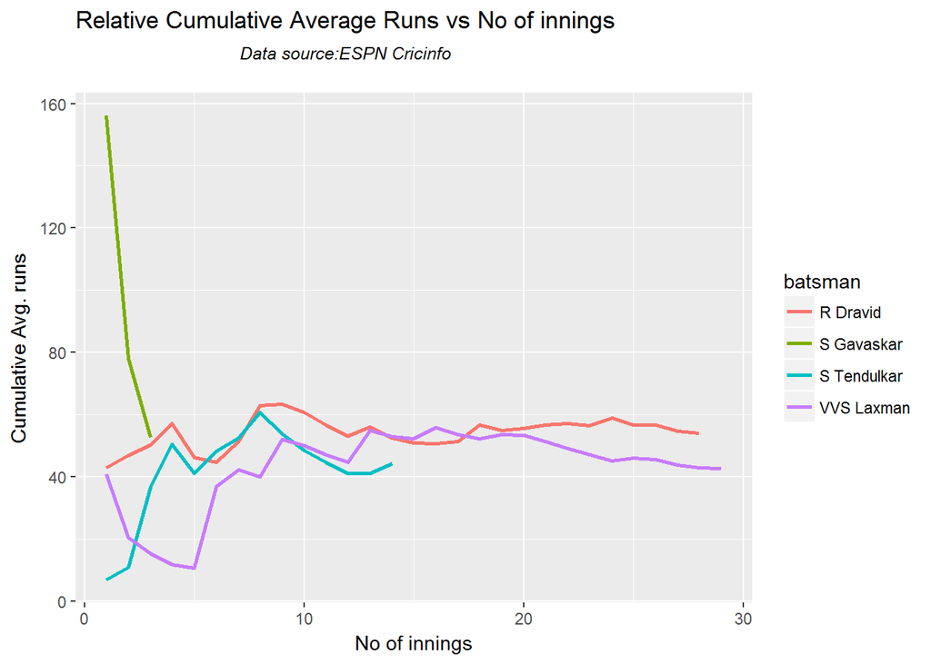

```r
relativeBatsmanCumulativeAvgRuns(frames,names)
```

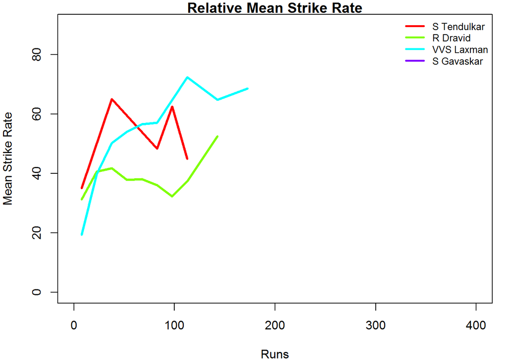

```r
# VVS Laxman followed by Dravid have a very consistent strike rate against the West Indies
relativeBatsmanSR(frames,names)
```

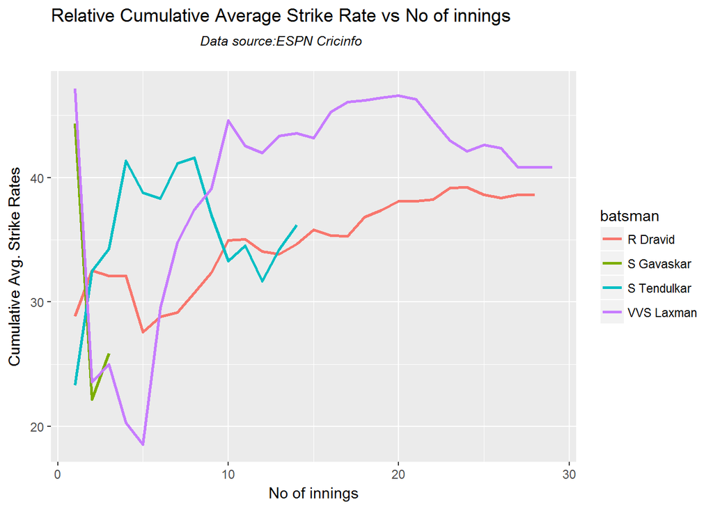

```r
relativeBatsmanCumulativeStrikeRate(frames,names)
```